# Beta Regression

Beta Regressionists

Author

Anaite Montes Bu

## Background

Regression analysis is a widely used statistical tool for examining the relationships between variables, particularly in exploring how changes in one variable influence another. It plays a crucial role in determining causal effects across numerous fields[1]. Among the various types of regression models, beta regression is specifically designed to handle continuous response variables confined to the open interval (0, 1), making it suitable for modeling rates, proportions, and other bounded data[2]. This model allows for flexibility by enabling both the mean response and the variability to be modeled as functions of covariates, making it ideal for bounded data.

The beta regression model addresses challenges posed by traditional models when dealing with bounded outcomes and has been extended to accommodate heteroscedasticity, where variance depends on covariates. Implemented in statistical packages like betareg in R, this model has become a valuable tool for analyzing real-world data, particularly when response variables are restricted within a certain range [3].

This paper synthesizes the literature on beta regression, including its theoretical foundations and practical applications. It also demonstrates beta regression’s use with the Suicide Rates Overview 1985 to 2016 dataset, which covers suicide trends across multiple countries and demographic groups over a 31-year period. The dataset includes variables such as country, year, sex, age group, suicide rate, and socio-economic factors like GDP and the Human Development Index (HDI). By using beta regression, we aim to model the suicide rates, which are continuous and bounded between 0 and 1, as functions of socio-economic factors.

The beta distribution, is characterized by the following probability density function (PDF) for a random variable:

$$f(y) = \begin{cases}
\frac{y^{\alpha-1}(1-y)^{\beta-1}}{B(\alpha,\beta)}, & 0 \le y \le 1 \\
0, & \text{elsewhere}
\end{cases}$$
Where $B(\alpha,\beta) = \int_0^1 y^{\alpha-1}(1-y)^{\beta-1} \ dy = \frac{\Gamma(\alpha) \Gamma(\beta)}{\Gamma(\alpha+\beta)}.$

**Theorem:**

$$E[Y] = \mu = \frac{\alpha}{\alpha+\beta} \ \ \ \text{and} \ \ \ V[Y] = \sigma^2 = \frac{\alpha\beta}{(\alpha+\beta)^2(\alpha+\beta+1)}$$
[4]

Here, α and β are shape parameters with α > 0 and β > 0. In the context of beta regression, the mean of the response variable is modeled by μ, and the dispersion is controlled by the precision parameter ϕ. The higher the value of ϕ, the lower the variance, leading to a more concentrated distribution around the mean.

## Methods

In this paper, we modeled suicide rates using beta regression, a specialized form of regression suitable for response variables that are bounded between 0 and 1. Since suicide rates are proportions (number of suicides per population) and fall within this range, traditional linear regression may not be appropriate due to potential violations of key assumptions, such as constant variance of the residuals. Beta regression, on the other hand, is designed to handle these challenges by accounting for the distribution and nature of the response variable.

The analysis used the ‘Suicide Rates Overview 1985 to 2016’ dataset, which includes variables such as Human Development Index (HDI), GDP per capita, sex, age group, and generation. A comprehensive overview of the demographic and economic factors related to suicide rates is summarized in Table 1. This information is crucial for understanding the context of the variables we examined in our beta regression model.

| Table 1: Suicide Demographic and Economic Factors From 1985 to 2016 |  |
| --- | --- |
| Characteristic | Overall (n=27820) |
| year (mean (SD)) | 2001.26 (8.47) |
| sex = male (%) | 13910 (50.0) |
| age (%) |  |
| 15-24 years | 4642 (16.7) |
| 25-34 years | 4642 (16.7) |
| 35-54 years | 4642 (16.7) |
| 5-14 years | 4610 (16.6) |
| 55-74 years | 4642 (16.7) |
| 75+ years | 4642 (16.7) |
| generation (%) |  |
| Boomers | 4990 (17.9) |
| G.I. Generation | 2744 ( 9.9) |
| Generation X | 6408 (23.0) |
| Generation Z | 1470 ( 5.3) |
| Millenials | 5844 (21.0) |
| Silent | 6364 (22.9) |
| HDI_year (mean (SD)) | 0.78 (0.09) |
| GDP_capita (mean (SD)) | 16866.46 (18887.58) |

To ensure the robustness of our model, we identified and removed influential data points based on Cook’s distance, leverage, and residual analysis. Data points exceeding specific thresholds were excluded from the analysis. This cleaning process improved the model’s fit and reduced the impact of outliers on the results.

The dependent variable, suicide rate, was modeled as a function of these socio-economic factors, with interaction terms considered where relevant. The beta regression was implemented with varying precision (phi) to account for differences in the variance of suicide rates. This allowed us to explore not only the relationship between predictors and the expected value of the suicide rate but also the precision of these predictions across different subgroups.

Data management and analysis were performed using R. The dataset was pre-processed to address missing values, ensuring a complete dataset for analysis. Descriptive statistics were calculated to summarize key characteristics, such as means and standard deviations for continuous variables and counts and percentages for categorical variables. We modeled suicide rates as a function of socio-economic factors including HDI, GDP per capita, sex, age group, and generation. Extended beta regression techniques were employed to analyze the relationship between these predictors and the suicide rate, incorporating bias correction and reduction strategies to enhance model accuracy. Additionally, beta regression trees were utilized to capture potential nonlinear relationships within the data while still accounting for the bounded nature of the response variable [5]. To evaluate model performance, we reported the pseudo R-squared value, a common measure for beta regression models.

## Analysis

The analysis evaluates two models: the Base Model and the Extended Model. Both models utilize beta regression to predict suicide rates, which are bounded between 0 and 1. The Base Model assumes that the precision (ϕ) is constant across all observations, indicating that the variance of the response variable does not depend on any covariates [2].

```r
library(betareg)
library(readr)

# Load and clean the dataset
suicide_dataset <- read_csv("master.csv")

# Rescale suicide rates and handle 0s and 1s
max_suicide_rate <- max(suicide_dataset$`suicides/100k pop`, na.rm = TRUE)
suicide_dataset$suicide_rate <- ifelse(suicide_dataset$`suicides/100k pop` == 0, 0.001,
                                        ifelse(suicide_dataset$`suicides/100k pop` == max_suicide_rate, 0.999,
                                               suicide_dataset$`suicides/100k pop` / max_suicide_rate))

# Rename
names(suicide_dataset)[names(suicide_dataset) == "HDI for year"] <- "HDI_year"
names(suicide_dataset)[names(suicide_dataset) == "gdp_per_capita ($)"] <- "GDP_capita"

# Remove NA
suicide_dataset <- na.omit(suicide_dataset)

base_formula <- suicide_rate ~ HDI_year + GDP_capita + sex + age + generation

# Fit the base beta regression model
m_base <- betareg(base_formula, data = suicide_dataset)

# Summarize base model
summary(m_base)
```

```
Call:
betareg(formula = base_formula, data = suicide_dataset)

Quantile residuals:
    Min      1Q  Median      3Q     Max
-4.1674 -0.5500 -0.0590  0.4211  6.8962

Coefficients (mean model with logit link):
                            Estimate Std. Error z value Pr(>|z|)
(Intercept)               -5.751e+00  1.206e-01 -47.675  < 2e-16 ***
HDI_year                   3.598e+00  1.596e-01  22.542  < 2e-16 ***
GDP_capita                -6.410e-06  6.436e-07  -9.960  < 2e-16 ***
sexmale                    8.054e-01  1.874e-02  42.974  < 2e-16 ***
age25-34 years             8.445e-02  3.275e-02   2.579 0.009919 **
age35-54 years             7.030e-02  4.017e-02   1.750 0.080121 .
age5-14 years             -9.587e-01  4.572e-02 -20.969  < 2e-16 ***
age55-74 years            -1.578e-01  5.326e-02  -2.964 0.003039 **
age75+ years              -2.110e-01  6.031e-02  -3.498 0.000469 ***
generationG.I. Generation  5.066e-01  4.829e-02  10.491  < 2e-16 ***
generationGeneration X    -2.179e-01  3.719e-02  -5.859 4.66e-09 ***
generationGeneration Z    -4.926e-01  6.754e-02  -7.293 3.03e-13 ***
generationMillenials      -4.237e-01  4.602e-02  -9.207  < 2e-16 ***
generationSilent           9.773e-02  3.719e-02   2.628 0.008593 **

Phi coefficients (precision model with identity link):
      Estimate Std. Error z value Pr(>|z|)
(phi)  16.4326     0.2924   56.19   <2e-16 ***
---
Signif. codes:  0 '***' 0.001 '**' 0.01 '*' 0.05 '.' 0.1 ' ' 1

Type of estimator: ML (maximum likelihood)
Log-likelihood: 1.908e+04 on 15 Df
Pseudo R-squared: 0.4623
Number of iterations: 45 (BFGS) + 6 (Fisher scoring)
```

The Base Model focuses solely on modeling the mean suicide rate as a function of covariates, assuming constant precision across observations. The results indicate strong relationships between suicide rates and the included covariates.

**Extended** **Beta** **Regression**

The Extended Model models both the mean and the precision as functions of covariates [2]. It provides more flexibility by allowing the precision (or variance) to change depending on certain variables (HDI_year and GDP_capita). Bias correction and bias reduction techniques ensure more accurate inference by shrinking overly optimistic parameter estimates.

```r
m1 <- suicide_rate ~ HDI_year + GDP_capita + sex + age + generation | HDI_year + GDP_capita


# Fit beta regression models
suicide_ml <- betareg(m1, data = suicide_dataset, type = "ML")
suicide_bc <- betareg(m1, data = suicide_dataset, type = "BC")
suicide_br <- betareg(m1, data = suicide_dataset, type = "BR")

summary(suicide_bc)
```

```
Call:
betareg(formula = m1, data = suicide_dataset, type = "BC")

Quantile residuals:
    Min      1Q  Median      3Q     Max
-4.5019 -0.5515 -0.0544  0.4490  6.5013

Coefficients (mean model with logit link):
                            Estimate Std. Error z value Pr(>|z|)
(Intercept)               -5.490e+00  1.530e-01 -35.872  < 2e-16 ***
HDI_year                   3.308e+00  2.030e-01  16.297  < 2e-16 ***
GDP_capita                -8.702e-06  7.265e-07 -11.978  < 2e-16 ***
sexmale                    8.151e-01  1.847e-02  44.125  < 2e-16 ***
age25-34 years             8.994e-02  3.226e-02   2.787  0.00531 **
age35-54 years             8.603e-02  3.967e-02   2.169  0.03010 *
age5-14 years             -9.579e-01  4.562e-02 -20.998  < 2e-16 ***
age55-74 years            -1.345e-01  5.281e-02  -2.546  0.01090 *
age75+ years              -1.821e-01  5.994e-02  -3.038  0.00238 **
generationG.I. Generation  4.913e-01  4.812e-02  10.208  < 2e-16 ***
generationGeneration X    -2.116e-01  3.688e-02  -5.738  9.6e-09 ***
generationGeneration Z    -5.561e-01  6.738e-02  -8.253  < 2e-16 ***
generationMillenials      -4.287e-01  4.574e-02  -9.372  < 2e-16 ***
generationSilent           9.104e-02  3.668e-02   2.482  0.01308 *

Phi coefficients (precision model with log link):
             Estimate Std. Error z value Pr(>|z|)
(Intercept) 2.149e+00  2.078e-01  10.344  < 2e-16 ***
HDI_year    6.433e-01  2.881e-01   2.233   0.0255 *
GDP_capita  8.314e-06  1.150e-06   7.232 4.75e-13 ***
---
Signif. codes:  0 '***' 0.001 '**' 0.01 '*' 0.05 '.' 0.1 ' ' 1

Type of estimator: BC (bias-corrected)
Log-likelihood: 1.917e+04 on 17 Df
Pseudo R-squared: 0.4625
Number of iterations: 33 (BFGS) + 2 (Fisher scoring)
```

The bias-corrected results highlight similar trends in the mean model, with HDI ($\beta$ = 3.3, p < 0.001), GDP per capita ($\beta$ = -8.7e-6, p < 0.001), and sex ($\beta$ =0.82, p < 0.001) remaining significant predictors of suicide rates. Age groups and generational differences also show consistent patterns with the Base Model.

**Beta** **Regression** **Trees**

The beta regression tree shown in Figure 1, titled “Beta Regression Tree for Predicting Suicide Rate Based on Human Development Index (HDI)”, models the suicide rate as a function of the Human Development Index for a given year (HDI_year). This tree illustrates how different HDI_year thresholds impact the distribution of suicide rates across various population groups.

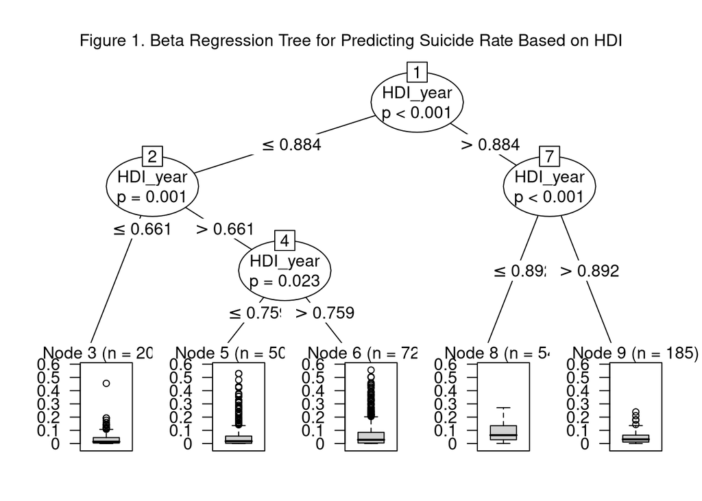

```r
library(partykit)
set.seed(123)

# Randomly sample 20% of the data
sample_indices <- sample(seq_len(nrow(suicide_dataset)), size = 0.2 * nrow(suicide_dataset))
suicide_sample <- suicide_dataset[sample_indices, ]

# Fit the model on the sample
suicide_tree <- betatree(suicide_rate ~ HDI_year,
                         data = suicide_sample,
                         minsplit = 20,
                         control = betatree.control(maxdepth = 3))

# Plot the resulting tree
plot(suicide_tree, main = "Figure 1. Beta Regression Tree for Predicting Suicide Rate Based on HDI")
```

Each split in the tree represents a statistically significant threshold in HDI_year, as indicated by the associated p-values. The first major split at an HDI_year threshold of 0.884 (p < 0.001) partitions the data into two primary branches, where cases with HDI_year values less than or equal to 0.884 move left, and those with values greater than 0.884 move right. Additional splits occur at HDI_year thresholds of 0.661, 0.759, and 0.892, refining the groups further based on HDI levels that significantly differentiate the suicide rate distribution.

**Diagnostic** **Plots**

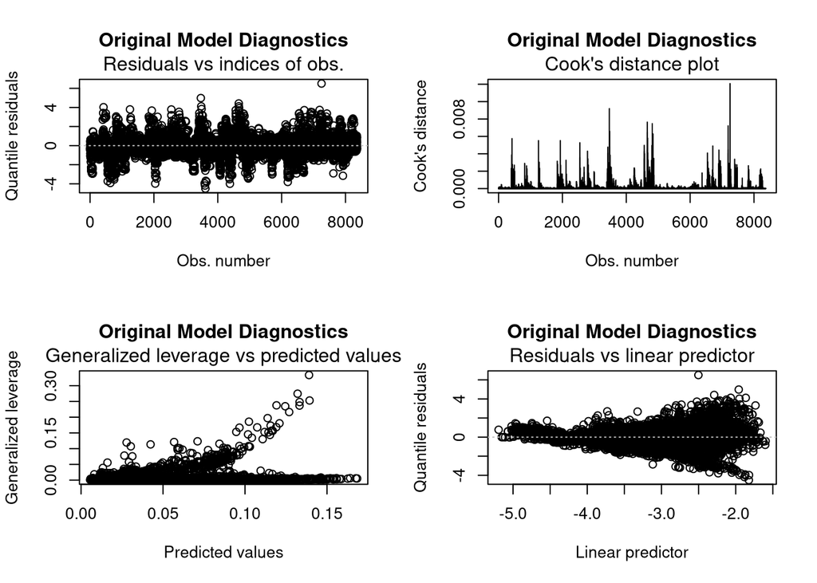

```r
par(mfrow = c(2, 2))
plot(suicide_bc, main = "Original Model Diagnostics")
```

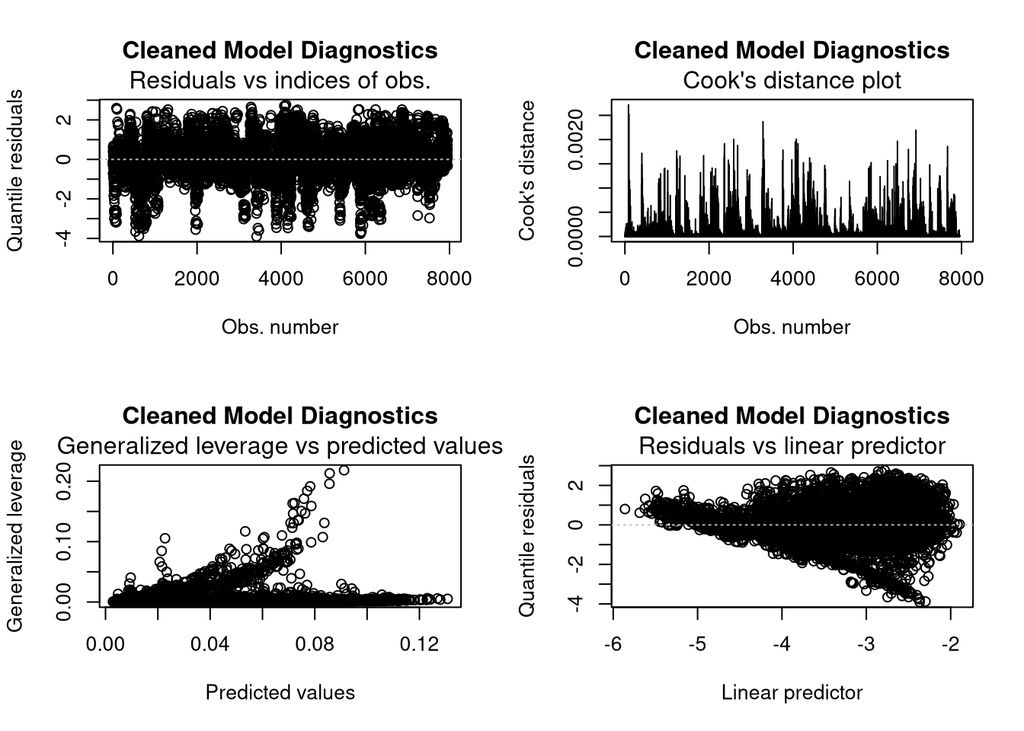

```r
#Identify influential points
cooks_dist <- cooks.distance(suicide_bc)
leverage <- hatvalues(suicide_bc)
residuals <- residuals(suicide_bc, type = "pearson")

# Set thresholds
cooks_threshold <- 4 / nrow(suicide_dataset)
leverage_threshold <- 2 * (length(coef(suicide_bc)) / nrow(suicide_dataset))
residual_threshold <- 3

#Identify extreme points
extreme_points <- which(cooks_dist > cooks_threshold |
                        leverage > leverage_threshold |
                        abs(residuals) > residual_threshold)

suicide_dataset_cleaned <- suicide_dataset[-extreme_points, ] #Remove extreme points

# Re-fit model
suicide_bc_cleaned <- betareg(suicide_bc$formula, data = suicide_dataset_cleaned)

#cleaned model
par(mfrow = c(2, 2))
plot(suicide_bc_cleaned, main = "Cleaned Model Diagnostics")
```

```r
par(mfrow = c(1, 1))  # Reset plot layout
```

Figure 2 illustrates the relationship between predicted suicide rates and the Human Development Index (HDI) per year, based on the bias-corrected model.

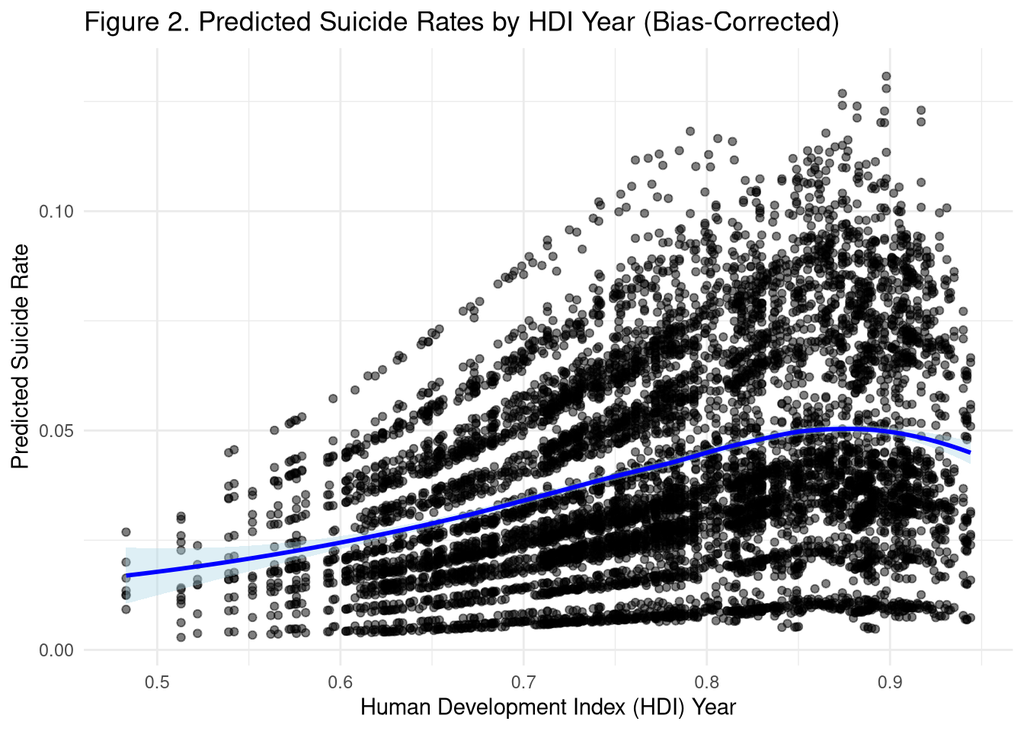

```r
library(betareg)
library(ggplot2)
library(dplyr)

# Fit the beta regression model using the bias-correction
suicide_bc_cleaned <- betareg(m1, data = suicide_dataset_cleaned, type = "BC")

new_data <- suicide_dataset_cleaned %>%
  select(HDI_year, GDP_capita, sex, age, generation) %>%
  distinct()

# new dataset
new_data$predicted_rate <- predict(suicide_bc_cleaned, newdata = new_data)

# Visualize plot
ggplot(new_data, aes(x = HDI_year, y = predicted_rate)) +
  geom_point(alpha = 0.5) +  # Scatter points
  geom_smooth(method = "loess", color = "blue", fill = "lightblue", se = TRUE) +  # Smooth line
  labs(title = "Figure 2. Predicted Suicide Rates by HDI Year (Bias-Corrected)",
       x = "Human Development Index (HDI) Year",
       y = "Predicted Suicide Rate") +
  theme_minimal()
```

## Results

The base beta regression model identified several significant predictors of suicide rates, including HDI_year, GDP_per_capita, sex, age group, and generation. Specifically, the coefficient for HDI_year in the base model was 3.60 (SE = 0.160) with a p-value of < 2e-16, indicating a strong positive association between HDI and suicide rates. Similarly, GDP_per_capita was negatively correlated with suicide rates, with a coefficient of -6.4e-06 (SE = 6.44e-07) and a p-value of < 2e-16. These results suggest that higher human development levels, as indicated by HDI, are associated with increased suicide rates, whereas higher GDP per capita correlates with lower suicide rates, in line with the socio-economic hypothesis of suicide prevention [6].

Table 2 presents the estimated coefficients and standard errors for both the base and extended beta regression models. The results highlight the significant impact of various socio-economic factors on suicide rates.

[output not shown]

The non-linear relationship between HDI_year and predicted suicide rates, visualized in the graph, further underscores the complexity of the factors influencing suicide. As HDI increases, suicide rates initially increase but begin to slightly decrease once HDI surpasses a certain threshold, suggesting that while socio-economic development is a crucial factor, other sociocultural and psychological factors may become more prominent at higher levels of development.

The precision model, which accounted for varying precision of the response variable, highlighted the need to incorporate this variability to achieve a more accurate understanding of suicide rates. This model improved the overall fit, with a pseudo R-squared value of 0.4625, compared to 0.4623 for the base model, signifying a modest improvement in capturing the complexity of the data.

## Conclusion

The results of this analysis underscore the critical role that socio-economic factors, particularly HDI and GDP per capita, play in determining suicide rates. Both models, base and extended, consistently show that higher HDI is linked to higher suicide rates, while higher GDP per capita is associated with lower rates. These findings suggest that while economic development plays a significant role in reducing suicide risk, the relationship is complex.

Males consistently exhibited higher suicide rates than females across both models, with a coefficient of 0.81 (SE = 0.019) for sex (Male), indicating a robust and significant gender difference in suicide rates. Age and generation factors also played important roles, with younger and older age groups, such as 5-14 years and 75+ years, having significantly lower suicide rates. This suggests that different socio-economic factors may impact suicide risk in different age cohorts, pointing to the importance of targeted interventions for middle-aged populations.

The extended model, which allowed for varying precision in the estimation, provided a more refined understanding of how HDI and GDP per capita interact with suicide rates. The results indicate that countries with higher HDI and GDP per capita tend to have more consistent and less variable suicide rates, while countries with lower HDI exhibit greater variability, pointing to socio-economic instability as a key factor in suicide risk. This model also improved the fit of the analysis, with slight increases in pseudo R-squared and log-likelihood values, suggesting that accounting for the variability in precision leads to more accurate predictions.

Beta regression, the modeling framework employed in this analysis, is particularly well-suited for situations where the response variable is bounded, such as suicide rates that lie between 0 and 1. Unlike linear regression, which can struggle with this type of data, beta regression provides a more appropriate framework by modeling continuous, proportional outcomes directly. This approach enables a more nuanced understanding of relationships between predictors and outcomes, especially when response variability, or precision, may differ across observations.

## References

[1]

E. A. Geissinger, C. L. L. Khoo, I. C. Richmond, S. J. M. Faulkner, and D. C. Schneider, “A case for beta regression in the natural sciences,” *Ecosphere*, vol. 13, no. 2, Feb. 2022.

[2]

S. Ferrari and F. Cribari-Neto, “Beta regression for modelling rates and proportions,” *J. Appl. Stat.*, vol. 31, no. 7, pp. 799–815, Aug. 2004.

[3]

F. Cribari-Neto and A. Zeileis, “Beta regression inR,” *J. Stat. Softw.*, vol. 34, no. 2, 2010.

[4]

D. D. Wackerly, *Mathematical statistics with applications*, 6th ed. Duxbury Press, 2002.

[5]

B. Grün, I. Kosmidis, and A. Zeileis, “Extended beta regression inR: Shaken, stirred, mixed, and partitioned,” *J. Stat. Softw.*, vol. 48, no. 11, 2012.

[6]

V. Lorant, D. Kapadia, J. Perelman, and DEMETRIQ study group, “Socioeconomic disparities in suicide: Causation or confounding?” *PLoS One*, vol. 16, no. 1, p. e0243895, Jan. 2021.